# hw3

5. It is well-known that ridge regression tends to give similar coefficient values to correlated variables, whereas the lasso may give quite different coefficient values to correlated variables. We will now explore this property in a very simple setting. Suppose that n = 2, p = 2, x11 = x12, x21 = x22. Furthermore, suppose that y1 +y2 = 0 and x11 +x21 = 0 and x12 +x22 = 0, so that the estimate for the intercept in a least squares, ridge regression, or lasso model is zero: βˆ0 = 0.
1. Write out the ridge regression optimization problem in this setting.
2. Argue that in this setting, the ridge coefficient estimates satisfy βˆ1 = βˆ2.
3. Write out the lasso optimization problem in this setting.
4. Argue that in this setting, the lasso coefficients βˆ1 and βˆ2 are not unique—in other words, there are many possible solutions to the optimization problem in (c). Describe these solutions.
8. In this exercise, we will generate simulated data, and will then use this data to perform best subset selection.
1. Use the rnorm() function to generate a predictor X of length n = 100, as well as a noise vector ϵ of length n = 100.

```r
X <- rnorm(100)
epsilon <- rnorm(100)
```

2. Generate a response vector Y of length n = 100 according to the model Y = β0 + β1X + β2X2 + β3X3 + ϵ, where β0, β1, β2, and β3 are constants of your choice.

```r
b_0 <- 5
b_1 <- 3
b_2 <- 6
b_3 <- 7
y <- b_0 + b_1*X + b_2*X^2 + b_3*X^3 + epsilon
```

3. Use the regsubsets() function to perform best subset selection in order to choose the best model containing the predictors X, X2,…,X10. What is the best model obtained according to Cp, BIC, and adjusted R2? Show some plots to provide evidence for your answer, and report the coefficients of the best model obtained. Note you will need to use the data.frame() function to create a single data set containing both X and Y .

```r
library(leaps)

set.seed(42)

df <- data.frame(y=y, x=X)
subset_fit <- regsubsets(y ~ I(X) + I(X^2)+ I(X^3) + I(X^4) + I(X^5) + I(X^6) + I(X^7) + I(X^8) + I(X^9) + I(X^10), data=df, nvmax=10)
reg_summary <- summary(subset_fit)

# Best model according to cp, bic, and adjr2
reg_cp <- which.min(reg_summary$cp)
reg_bic <- which.min(reg_summary$bic)
reg_adjr2 <- which.max(reg_summary$adjr2)

reg_cp
```

```
## [1] 3
```

```r
reg_bic
```

```
## [1] 3
```

```r
reg_adjr2
```

```
## [1] 3
```

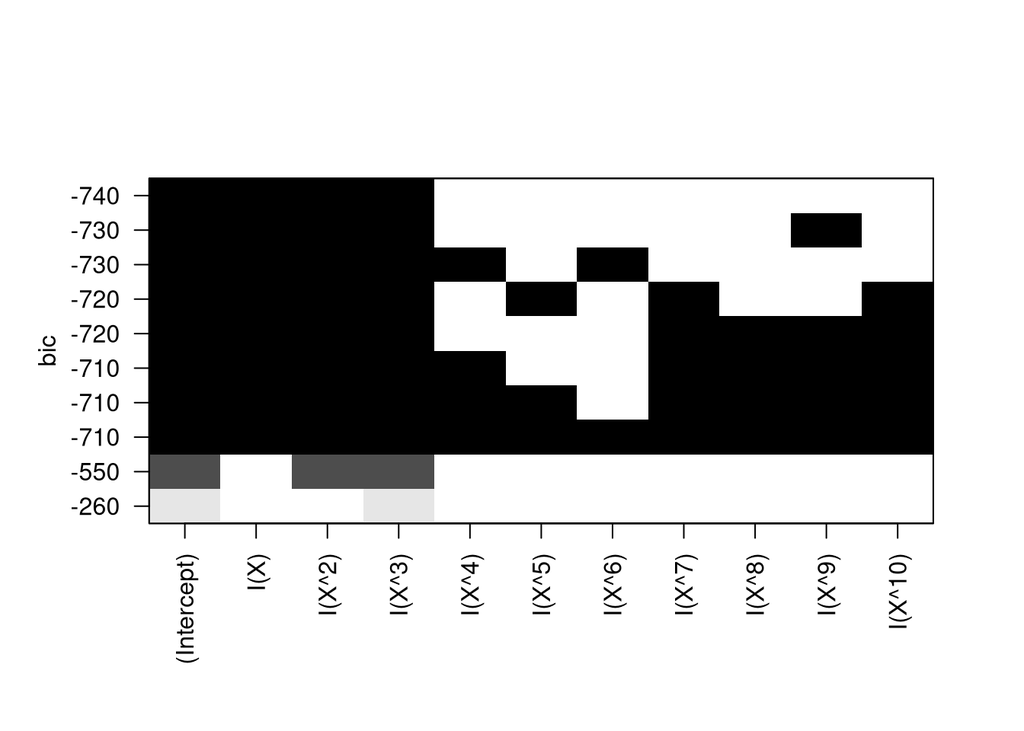

```r
# par(mfrow=c(2,2))

plot(subset_fit)
```

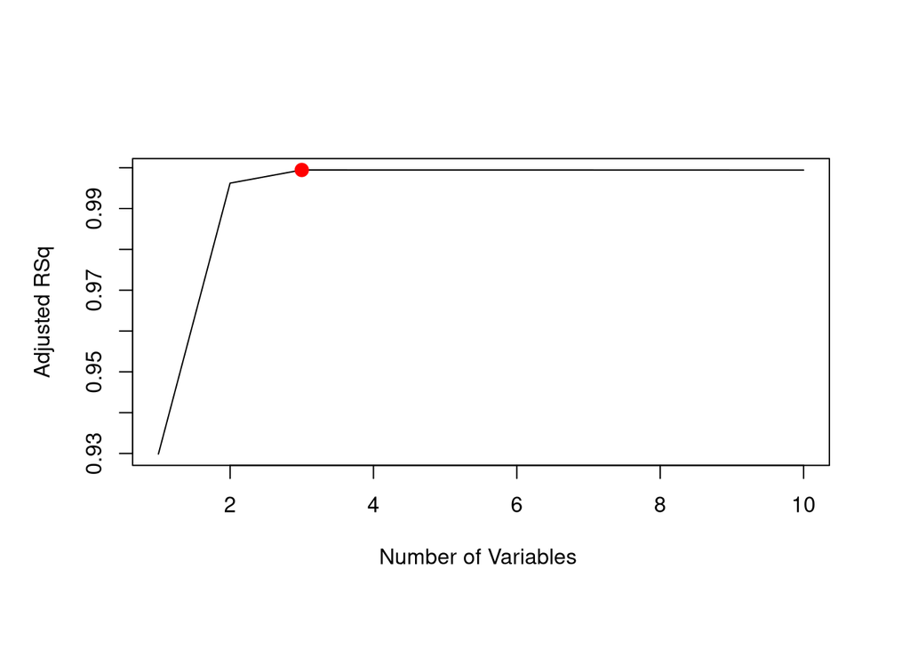

```r
plot(reg_summary$adjr2 ,xlab="Number of Variables ", ylab="Adjusted RSq",type="l")
points(which.max(reg_summary$adjr2),reg_summary$adjr2[which.max(reg_summary$adjr2)], col="red",cex=2,pch=20)
```

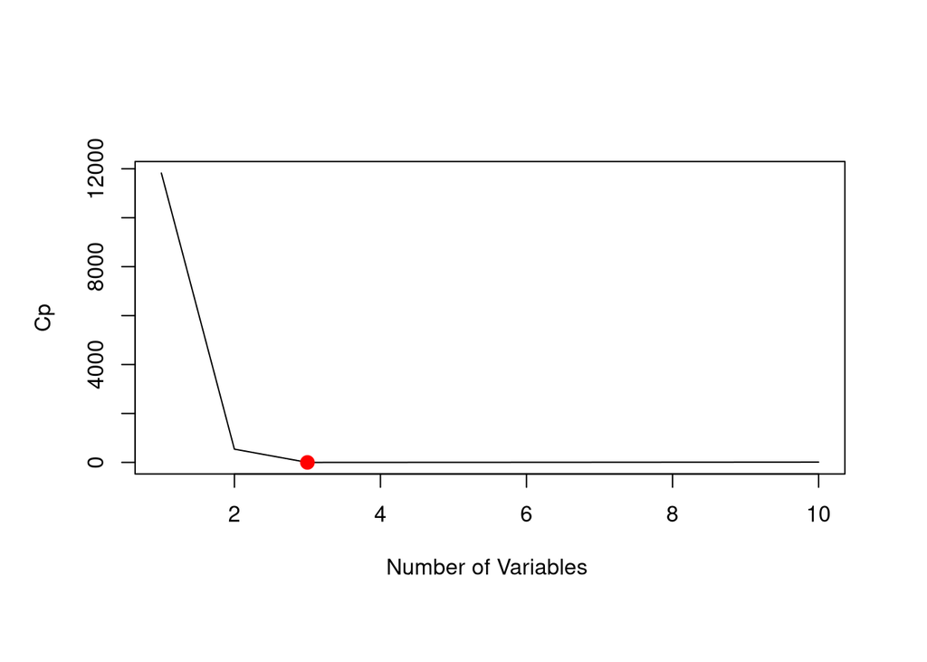

```r
plot(reg_summary$cp ,xlab="Number of Variables ",ylab="Cp", type='l')
points(which.min(reg_summary$cp),reg_summary$cp[which.min(reg_summary$cp)],col="red",cex=2,pch=20)
```

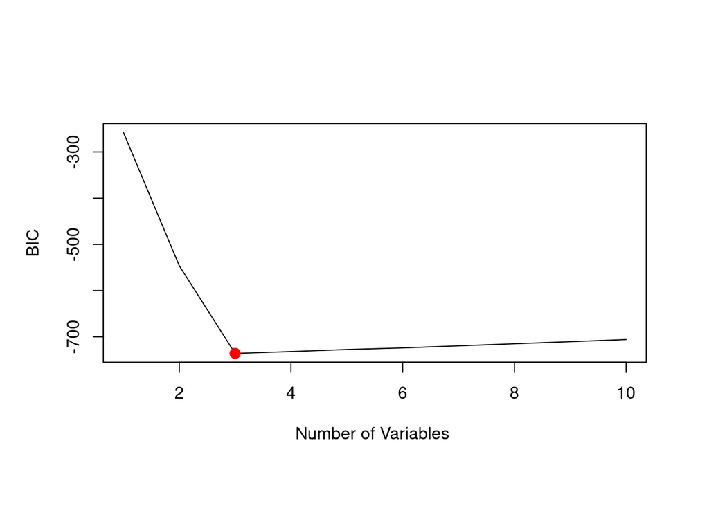

```r
plot(reg_summary$bic ,xlab="Number of Variables ",ylab="BIC",type='l')
points(which.min(reg_summary$bic),reg_summary$bic[which.min(reg_summary$bic)],col="red",cex=2,pch=20)
```

```r
# coefficients for best 3 variable model
coef(subset_fit, 3)
```

```
## (Intercept)        I(X)      I(X^2)      I(X^3)
##    5.112153    3.135779    5.964004    6.970476
```

4. Repeat (c), using forward stepwise selection and also using backwards stepwise selection. How does your answer compare to the results in (c)?

Forward selection:

```r
forward_fit <- regsubsets(y ~ I(X) + I(X^2)+ I(X^3) + I(X^4) + I(X^5) + I(X^6) + I(X^7) + I(X^8) + I(X^9) + I(X^10), data=df, nvmax=10, method="forward")
forward_summary <- summary(forward_fit)

# Best model according to cp, bic, and adjr2
which.min(forward_summary$cp)
```

```
## [1] 3
```

```r
which.min(forward_summary$bic)
```

```
## [1] 3
```

```r
which.max(forward_summary$adjr2)
```

```
## [1] 3
```

```r
# coefficients for best 3 variable model
coef(forward_fit, 3)
```

```
## (Intercept)        I(X)      I(X^2)      I(X^3)
##    5.112153    3.135779    5.964004    6.970476
```

Backward selection:

```r
backward_fit <- regsubsets(y ~ I(X) + I(X^2)+ I(X^3) + I(X^4) + I(X^5) + I(X^6) + I(X^7) + I(X^8) + I(X^9) + I(X^10), data=df, nvmax=10, method="backward")
backward_summary <- summary(backward_fit)

# Best model according to cp, bic, and adjr2
which.min(backward_summary$cp)
```

```
## [1] 3
```

```r
which.min(backward_summary$bic)
```

```
## [1] 3
```

```r
which.max(backward_summary$adjr2)
```

```
## [1] 3
```

```r
# coefficients for best 3 variable model
coef(backward_fit, 3)
```

```
## (Intercept)        I(X)      I(X^2)      I(X^3)
##    5.112153    3.135779    5.964004    6.970476
```

5. Now fit a lasso model to the simulated data, again using X, X2, …,X10 as predictors. Use cross-validation to select the optimal value of λ. Create plots of the cross-validation error as a function of λ. Report the resulting coefficient estimates, and discuss the results obtained.

```r
library(glmnet)
```

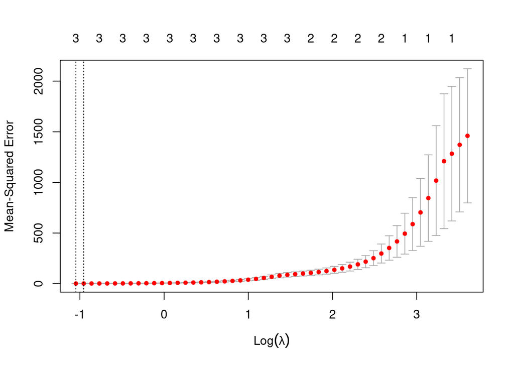

```r
X <- model.matrix(y ~ x + I(x^2) + I(x^3) + I(x^4) + I(x^5) + I(x^6) + I(x^7) + I(x^8) + I(x^9) + I(x^10), data=df)[, -1]
y <- df$y

set.seed(42)
cv_lasso <- cv.glmnet(X,y,alpha=1)
plot(cv_lasso, sign.lambda=1)
```

```r
min.lambda <- cv_lasso$lambda.min
min.lambda
```

```
## [1] 0.3506202
```

```r
prediction <- predict(cv_lasso, s = min.lambda, type = "coefficients")[1:11, ]
prediction
```

```
## (Intercept)           x      I(x^2)      I(x^3)      I(x^4)      I(x^5)
##    5.626803    3.315387    5.487727    6.799078    0.000000    0.000000
##      I(x^6)      I(x^7)      I(x^8)      I(x^9)     I(x^10)
##    0.000000    0.000000    0.000000    0.000000    0.000000
```

6. Now generate a response vector Y according to the model Y = β0 + β7X7 + ϵ, and perform best subset selection and the lasso. Discuss the results obtained.

```r
set.seed(42)
X <- rnorm(100)
e <- rnorm(100)

b_0 <- 5
b_7 <- 3
y <- b_0 + b_7*X^7 + e
```

Best subset selection:

```r
df <- data.frame(y=y, x=X)
diff_fit <- regsubsets(y ~ I(X) + I(X^2)+ I(X^3) + I(X^4) + I(X^5) + I(X^6) + I(X^7) + I(X^8) + I(X^9) + I(X^10), data=df, nvmax=10)
diff_summary <- summary(diff_fit)

# Best model according to cp, bic, and adjr2
which.min(diff_summary$cp)
```

```
## [1] 6
```

```r
which.min(diff_summary$bic)
```

```
## [1] 4
```

```r
which.max(diff_summary$adjr2)
```

```
## [1] 7
```

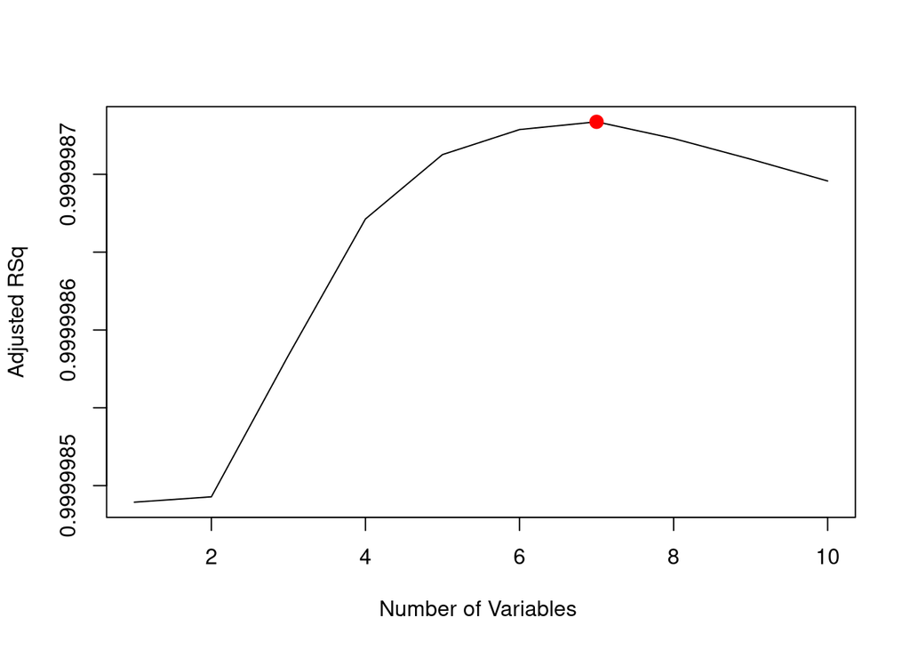

```r
plot(diff_summary$adjr2 ,xlab="Number of Variables ", ylab="Adjusted RSq",type="l")
points(which.max(diff_summary$adjr2),diff_summary$adjr2[which.max(diff_summary$adjr2)], col="red",cex=2,pch=20)
```

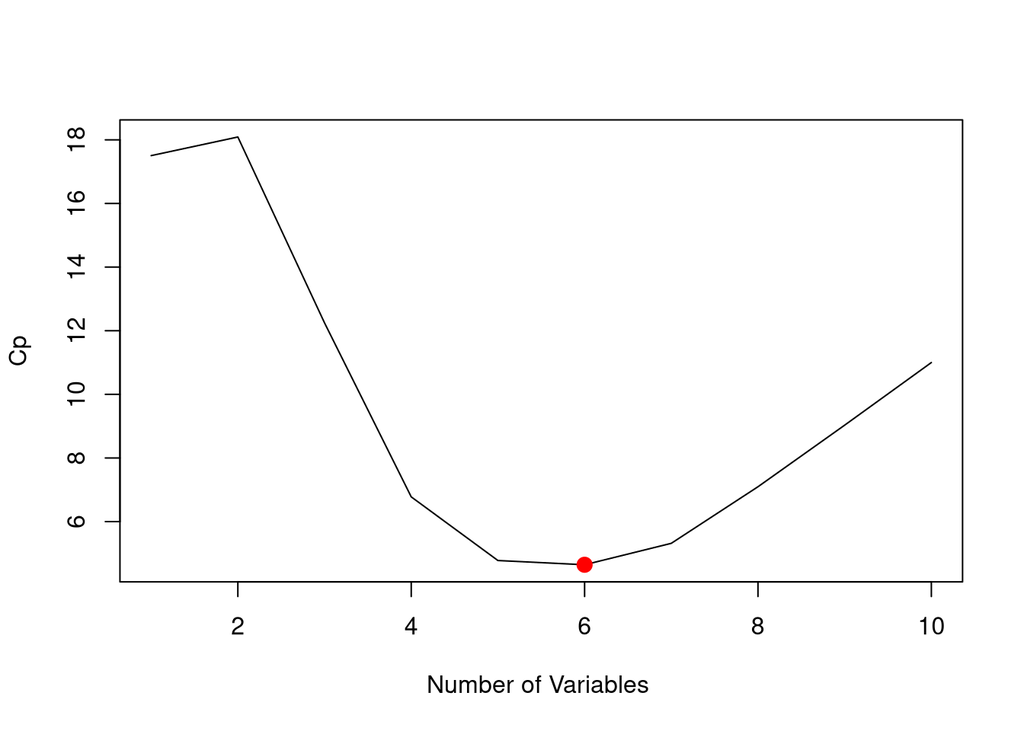

```r
plot(diff_summary$cp ,xlab="Number of Variables ",ylab="Cp", type='l')
points(which.min(diff_summary$cp),diff_summary$cp[which.min(diff_summary$cp)],col="red",cex=2,pch=20)
```

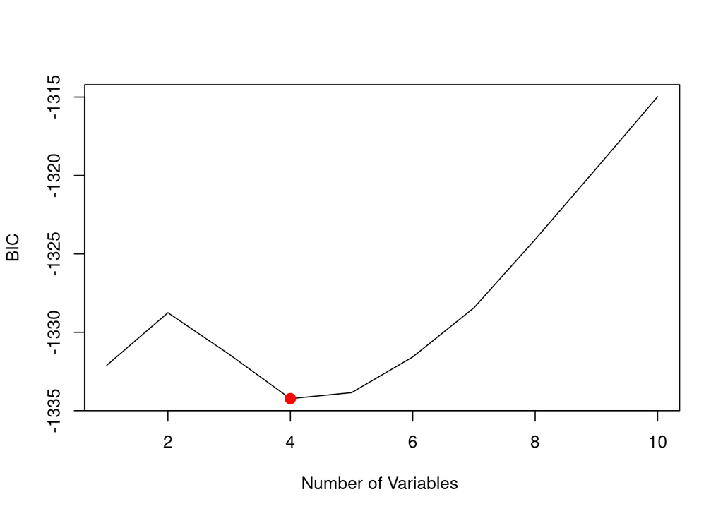

```r
plot(diff_summary$bic ,xlab="Number of Variables ",ylab="BIC",type='l')
points(which.min(diff_summary$bic),diff_summary$bic[which.min(diff_summary$bic)],col="red",cex=2,pch=20)
```

```r
# coefficients for best 4 variable model
coef(diff_fit, 4)
```

```
##  (Intercept)       I(X^3)       I(X^5)       I(X^7)       I(X^9)
##  4.879437515 -0.765855504  0.648983516  2.862371141  0.008358345
```

Lasso:

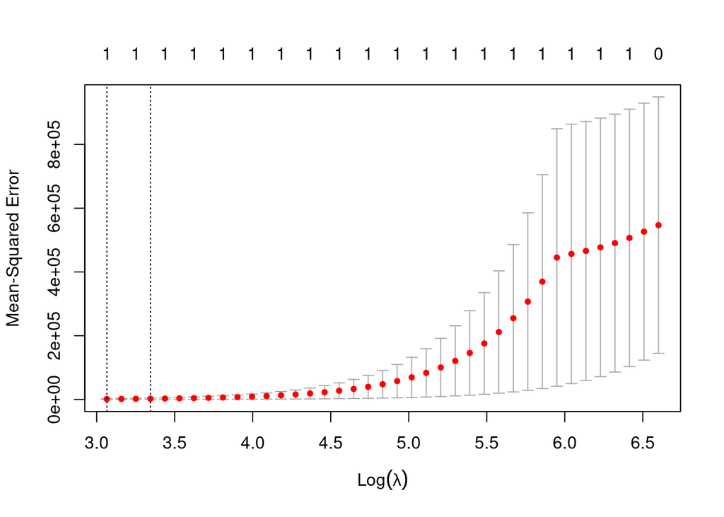

```r
X <- model.matrix(y ~ x + I(x^2) + I(x^3) + I(x^4) + I(x^5) + I(x^6) + I(x^7) + I(x^8) + I(x^9) + I(x^10), data=df)[, -1]
y <- df$y

set.seed(42)
diff_lasso <- cv.glmnet(X,y,alpha=1)
plot(diff_lasso, sign.lambda=1)
```

```r
min.lambda <- diff_lasso$lambda.min
min.lambda
```

```
## [1] 21.44145
```

```r
prediction <- predict(diff_lasso, s = min.lambda, type = "coefficients")[1:11, ]
prediction
```

```
## (Intercept)           x      I(x^2)      I(x^3)      I(x^4)      I(x^5)
##    1.773171    0.000000    0.000000    0.000000    0.000000    0.000000
##      I(x^6)      I(x^7)      I(x^8)      I(x^9)     I(x^10)
##    0.000000    2.912477    0.000000    0.000000    0.000000
```

In this instance, when the min lambda was used it only chose one predictor, x^7. This is because the response vector created in this problem contained x^7.

9. In this exercise, we will predict the number of applications received using the other variables in the College data set.
1. Split the data set into a training set and a test set.

```r
require(ISLR)
data(College)
attach(College)

set.seed(42)

college_train = sample(1:nrow(College), nrow(College) * 0.7)
college_test = -college_train
y_test <- Apps[college_test]
```

2. Fit a linear model using least squares on the training set, and report the test error obtained.

```r
college_ols <- lm(Apps ~ ., data = College, subset = college_train)

summary(college_ols)
```

```
##
## Call:
## lm(formula = Apps ~ ., data = College, subset = college_train)
##
## Residuals:
##     Min      1Q  Median      3Q     Max
## -2876.7  -408.4   -51.6   307.2  6736.7
##
## Coefficients:
##               Estimate Std. Error t value Pr(>|t|)
## (Intercept) -778.80347  480.64037  -1.620 0.105759
## PrivateYes  -532.78443  153.87926  -3.462 0.000579 ***
## Accept         1.34195    0.05886  22.800  < 2e-16 ***
## Enroll        -0.37784    0.19640  -1.924 0.054916 .
## Top10perc     43.11150    6.26659   6.880 1.71e-11 ***
## Top25perc    -13.15544    4.95672  -2.654 0.008194 **
## F.Undergrad    0.07522    0.03398   2.214 0.027286 *
## P.Undergrad    0.02938    0.03345   0.878 0.380112
## Outstate      -0.05828    0.02221  -2.624 0.008949 **
## Room.Board     0.17203    0.05799   2.967 0.003148 **
## Books         -0.06827    0.27881  -0.245 0.806644
## Personal       0.03323    0.07412   0.448 0.654081
## PhD           -9.99553    5.64388  -1.771 0.077134 .
## Terminal      -3.60036    6.23641  -0.577 0.563975
## S.F.Ratio     20.62650   14.75332   1.398 0.162676
## perc.alumni   -4.40869    4.86688  -0.906 0.365428
## Expend         0.10643    0.01479   7.197 2.14e-12 ***
## Grad.Rate     10.04291    3.42233   2.935 0.003487 **
## ---
## Signif. codes:  0 '***' 0.001 '**' 0.01 '*' 0.05 '.' 0.1 ' ' 1
##
## Residual standard error: 976.7 on 525 degrees of freedom
## Multiple R-squared:  0.9296, Adjusted R-squared:  0.9273
## F-statistic: 407.8 on 17 and 525 DF,  p-value: < 2.2e-16
```

```r
college_predict <- predict(college_ols, College[college_test, ])
college_error <- mean((college_predict - y_test)^2)
college_error
```

```
## [1] 1583501
```

The test MSE is 1583501

3. Fit a ridge regression model on the training set, with λ chosen by cross-validation. Report the test error obtained.

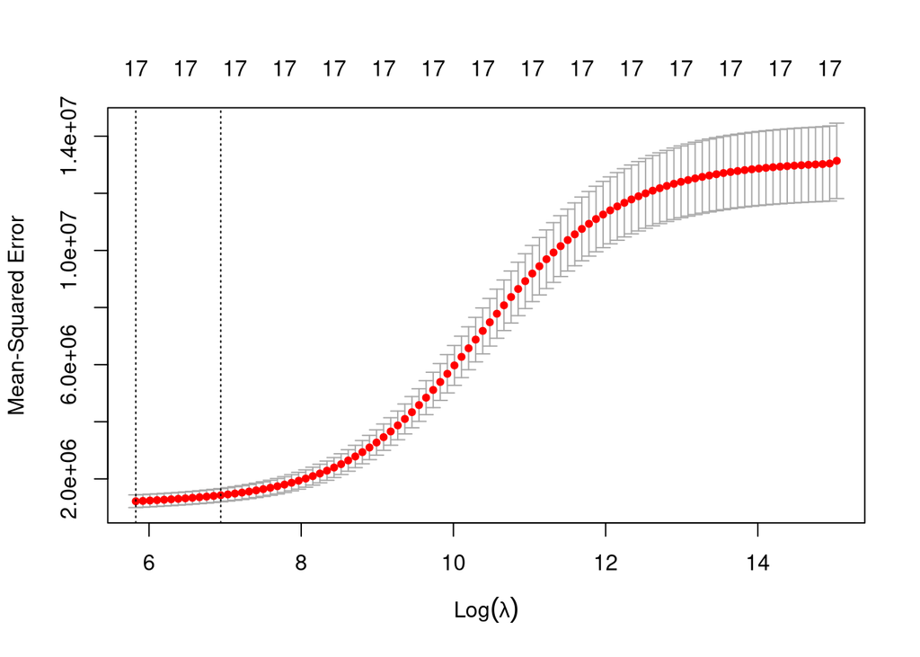

```r
matrix <- model.matrix(Apps~., data=College)[, -1]
matrix.train <- matrix[college_train,]
y <- College$Apps
y_train <- y[college_train]

ridge <- cv.glmnet(matrix.train, y_train, alpha=0)
plot(ridge, sign.lambda = 1)
```

```r
ridge.lambda <- ridge$lambda.min

ridge_predict <- predict(ridge, s = ridge.lambda, newx = matrix[college_test, ])
ridge_error <- mean((ridge_predict - y_test)^2)
ridge_error
```

```
## [1] 2828195
```

The test error for ridge is 2828195.

4. Fit a lasso model on the training set, with λ chosen by crossvalidation. Report the test error obtained, along with the number of non-zero coefficient estimates.

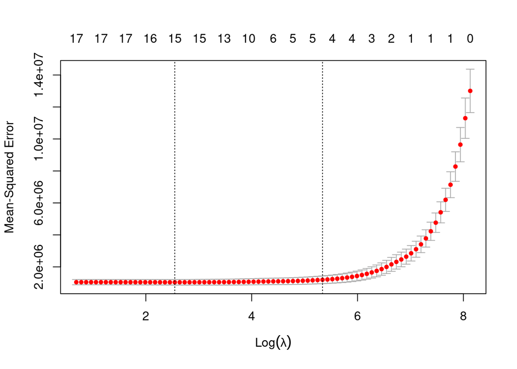

```r
lasso <- cv.glmnet(matrix.train, y_train, alpha=1)
plot(lasso, sign.lambda=1)
```

```r
lasso.lambda <- lasso$lambda.min
lasso.lambda
```

```
## [1] 12.77064
```

```r
lasso_predict <- predict(lasso, s = lasso.lambda, newx = matrix[college_test, ])
lasso_error <- mean((lasso_predict - y_test)^2)
lasso_error
```

```
## [1] 1679044
```

```r
lasso.c <- predict(lasso,type="coefficients", s=lasso.lambda)[1:17,]
length(lasso.c[lasso.c != 0])
```

```
## [1] 15
```

Lasso produced 15 coefficient estimates that are not 0

5. Fit a PCR model on the training set, with M chosen by crossvalidation. Report the test error obtained, along with the value of M selected by cross-validation.

```r
library(pls)
pcr_fit <- pcr(Apps~., data=College, subset=college_train, scale=TRUE, validation ="CV")
summary(pcr_fit)
```

```
## Data:    X dimension: 543 17
##  Y dimension: 543 1
## Fit method: svdpc
## Number of components considered: 17
##
## VALIDATION: RMSEP
## Cross-validated using 10 random segments.
##        (Intercept)  1 comps  2 comps  3 comps  4 comps  5 comps  6 comps
## CV            3626     3535     1694     1710     1704     1302     1289
## adjCV         3626     3535     1692     1712     1731     1287     1285
##        7 comps  8 comps  9 comps  10 comps  11 comps  12 comps  13 comps
## CV        1228     1218     1207      1198      1204      1198      1201
## adjCV     1222     1213     1204      1195      1201      1195      1198
##        14 comps  15 comps  16 comps  17 comps
## CV         1200      1204      1057      1038
## adjCV      1197      1202      1053      1034
##
## TRAINING: % variance explained
##       1 comps  2 comps  3 comps  4 comps  5 comps  6 comps  7 comps  8 comps
## X      32.285    58.17    65.38    70.99    76.32    81.24    84.75    88.04
## Apps    5.852    78.67    78.69    79.58    88.05    88.05    89.22    89.34
##       9 comps  10 comps  11 comps  12 comps  13 comps  14 comps  15 comps
## X       90.89     93.30     95.46     97.16     98.20     98.93     99.43
## Apps    89.52     89.73     89.77     90.03     90.03     90.04     90.15
##       16 comps  17 comps
## X        99.81    100.00
## Apps     92.52     92.96
## (234 observations deleted due to missingness)
```

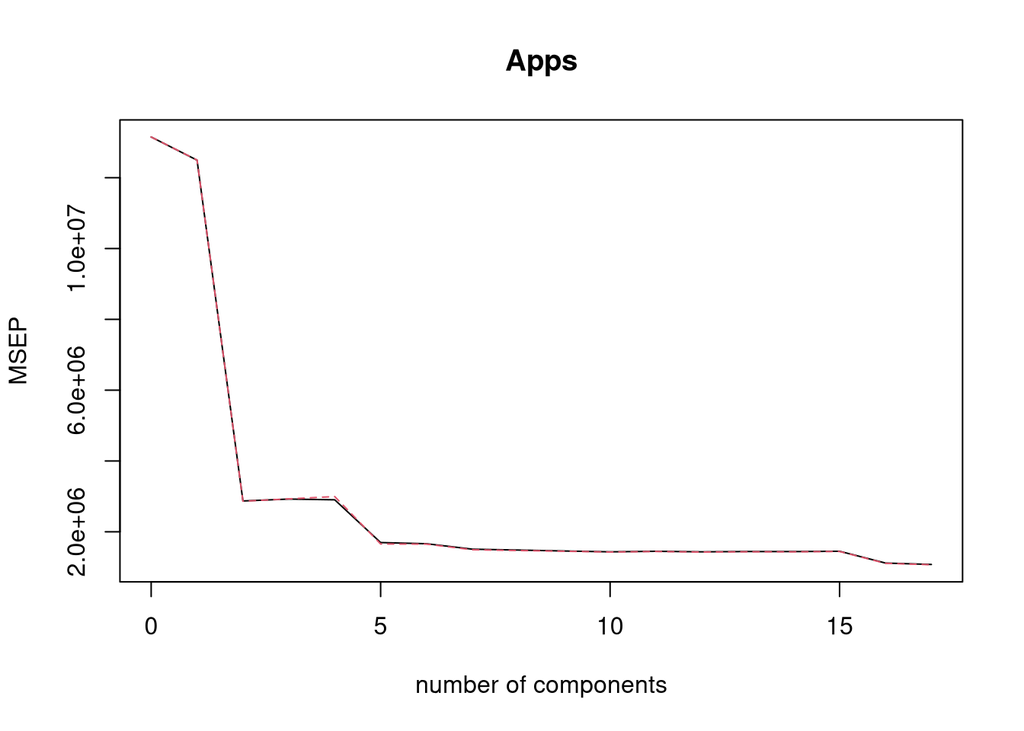

```r
validationplot(pcr_fit,val.type="MSEP")
```

The lowest CV error is when all 17 variables are used

```r
pcr_pred <- predict(pcr_fit,matrix[college_test,], ncomp=17)
pcr_error <- mean((pcr_pred-y_test)^2)
pcr_error
```

```
## [1] 1583501
```

The test MSE is 1583501

6. Fit a PLS model on the training set, with M chosen by crossvalidation. Report the test error obtained, along with the value of M selected by cross-validation.

```r
pls_fit <- plsr(Apps~., data=College, subset=college_train, scale=TRUE, validation="CV")
summary(pls_fit)
```

```
## Data:    X dimension: 543 17
##  Y dimension: 543 1
## Fit method: kernelpls
## Number of components considered: 17
##
## VALIDATION: RMSEP
## Cross-validated using 10 random segments.
##        (Intercept)  1 comps  2 comps  3 comps  4 comps  5 comps  6 comps
## CV            3626     1548     1338     1161     1151     1088     1046
## adjCV         3626     1546     1339     1159     1143     1075     1041
##        7 comps  8 comps  9 comps  10 comps  11 comps  12 comps  13 comps
## CV        1029     1023     1019      1020      1020      1020      1021
## adjCV     1025     1020     1016      1016      1017      1017      1017
##        14 comps  15 comps  16 comps  17 comps
## CV         1021      1021      1021      1021
## adjCV      1017      1017      1017      1017
##
## TRAINING: % variance explained
##       1 comps  2 comps  3 comps  4 comps  5 comps  6 comps  7 comps  8 comps
## X       26.48    48.43    63.31    66.25    69.14    74.08    77.07    81.61
## Apps    82.31    86.82    90.31    91.32    92.32    92.70    92.87    92.90
##       9 comps  10 comps  11 comps  12 comps  13 comps  14 comps  15 comps
## X       84.08     85.22     87.73     91.02     93.29     95.83     97.26
## Apps    92.92     92.95     92.96     92.96     92.96     92.96     92.96
##       16 comps  17 comps
## X        99.14    100.00
## Apps     92.96     92.96
## (234 observations deleted due to missingness)
```

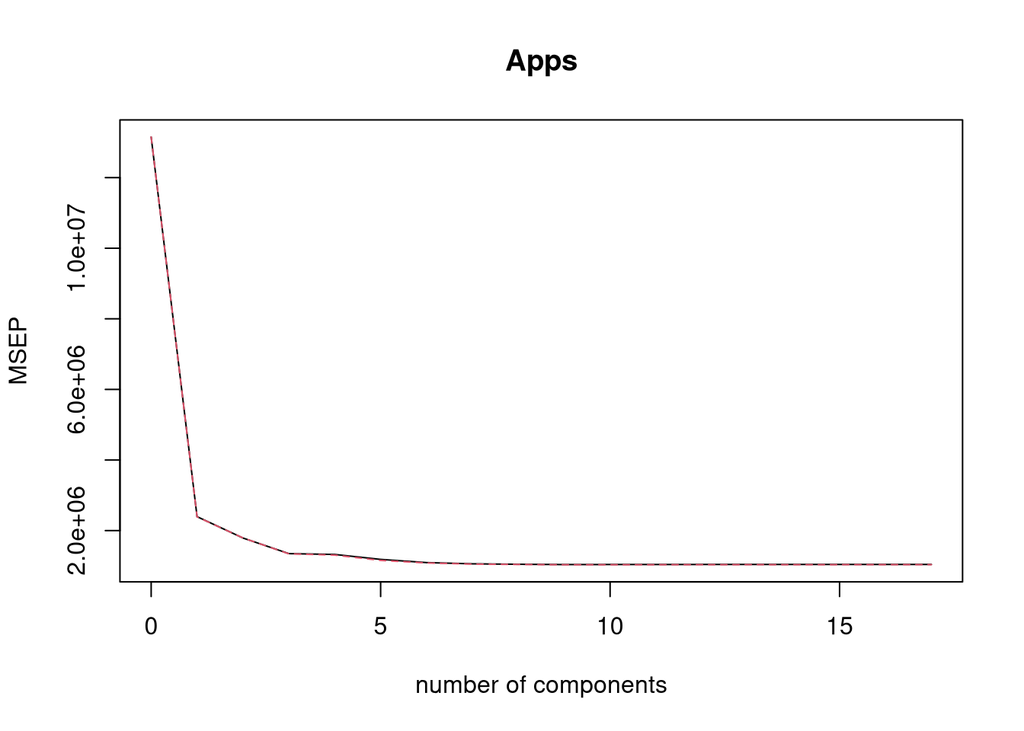

```r
validationplot(pls_fit,val.type="MSEP")
```

```r
pls_pred <- predict(pls_fit,matrix[college_test,],ncomp=10)
pls_error <- mean((pls_pred-y_test)^2)
pls_error
```

```
## [1] 1594881
```

7. Comment on the results obtained. How accurately can we predict the number of college applications received? Is there much difference among the test errors resulting from these five approaches?

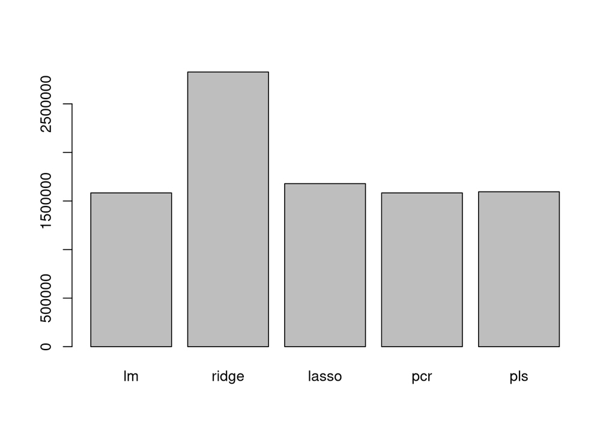

```r
results <- c(college_error, ridge_error, lasso_error, pcr_error, pls_error)
names(results) <- c("lm", "ridge", "lasso", "pcr", "pls")
barplot(results)
```

```r
print(sort(results))
```

```
##     pcr      lm     pls   lasso   ridge
## 1583501 1583501 1594881 1679044 2828195
```